# MP4

Jonah Kotzen, Ava Skogstrom, Conor Booth

2024-04-17

# Measurements

### Total Wing Area (A)

We used the ruler and shape info features in SketchUp to determine A A = chord (c) *x* span (s) (an approximation) Laridae: c = 20.6623 mm, s = 60.1978 mm, A = 1243.825 sq mm Alcidae: c = 42 mm, s = 52 mm, A = 2184 sq mm

### Span (S)

We used the ruler and shape info features in SketchUp to determine S Laridae: 60.1978 mm Alcidae: 52 mm

### Wetted Area (Aw)

We used the ruler and shape info features in SketchUp to determine Aw The wetted area is surface area of the wing in contact with the air flow Laridae: 165.368118 sq mm Alcidae: 104 sq mm

# Compiled Tibbles

### Compiled Wing Data into Tibble

```r
wing_data_calc
```

```
## # A tibble: 2 × 5
##   Bird_Family Chord_mm Span_mm Total_Wing_Area_sq_mm Wetted_Area_sq_mm
##   <chr>          <dbl>   <dbl>                 <dbl>             <dbl>
## 1 Laridae         20.7    60.2                 1244.              165.
## 2 Alcidae         42      52                   2184               104
```

### Compiled Lift and Drag Data into Tibble

```r
averages_tibble
```

```
## # A tibble: 2 × 3
##   Bird_Family Average_Lift Average_Drag
##   <chr>              <dbl>        <dbl>
## 1 Alcidae             1.78         2.21
## 2 Laridae            66.7          6.22
```

### Compiled Coefficients & Total Data into Tibble

```r
complete_data
```

```
## # A tibble: 2 × 11
##   Bird_Family Chord_mm Span_mm Total_Wing_Area_sq_mm Wetted_Area_sq_mm
##   <chr>          <dbl>   <dbl>                 <dbl>             <dbl>
## 1 Laridae         20.7    60.2                 1244.              165.
## 2 Alcidae         42      52                   2184               104
## # ℹ 6 more variables: Average_Lift <dbl>, Average_Drag <dbl>, C_D <dbl>,
## #   C_L <dbl>, L_to_D_ratio <dbl>, AR <dbl>
```

# Graphs

## Class Data Graph

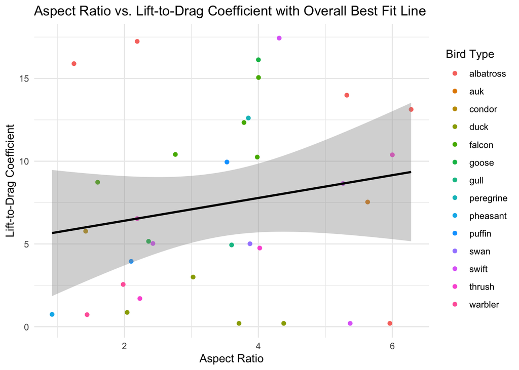

This scatter plot with a fitted line and confidence interval shows that, overall, birds with higher aspect ratios tend to have higher lift-to-drag coefficients, suggesting more efficient flight capabilities across species.

```r
ggplot(wing_data, aes(x = AR, y = Cl.Cd, color = bird)) +
  geom_point() +
  geom_smooth(method = "lm", se = TRUE, color = "black") +  # Best fit line for all data with CI
  theme_minimal() +
  labs(title = "Aspect Ratio vs. Lift-to-Drag Coefficient with Overall Best Fit Line",
       x = "Aspect Ratio",
       y = "Lift-to-Drag Coefficient") +
  scale_color_discrete(name = "Bird Type")
```

## Comparison of Wing Areas b/w Specimens

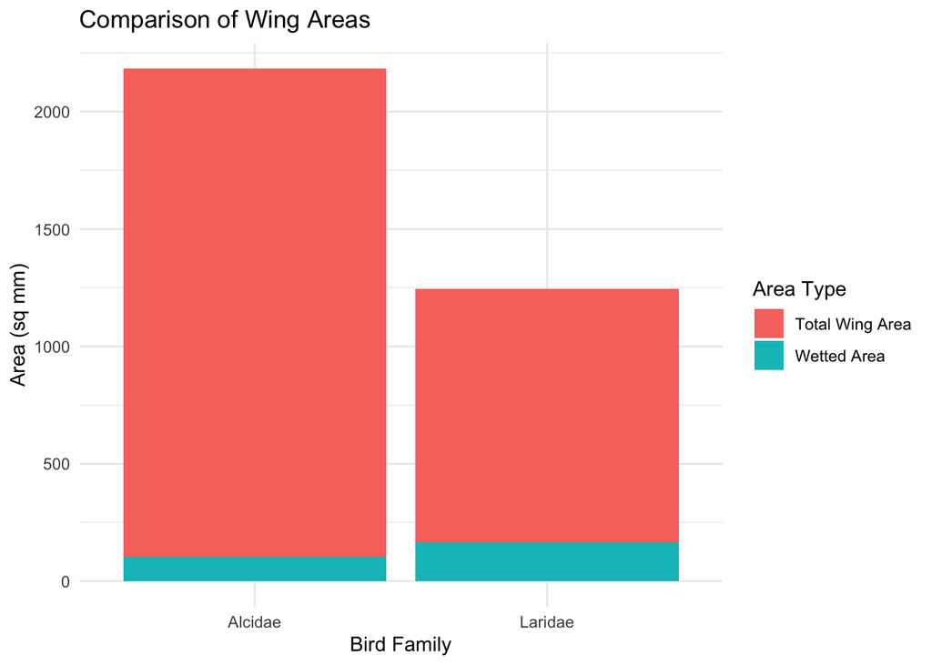

```r
ggplot(wing_data_calc, aes(x = Bird_Family)) +
  geom_bar(aes(y = Total_Wing_Area_sq_mm, fill = "Total Wing Area"), stat = "identity", position = "dodge") +
  geom_bar(aes(y = Wetted_Area_sq_mm, fill = "Wetted Area"), stat = "identity", position = "dodge") +
  labs(title = "Comparison of Wing Areas",
       x = "Bird Family",
       y = "Area (sq mm)",
       fill = "Area Type") +
  theme_minimal()
```

## Comparison of Lift over Time b/w Specimens

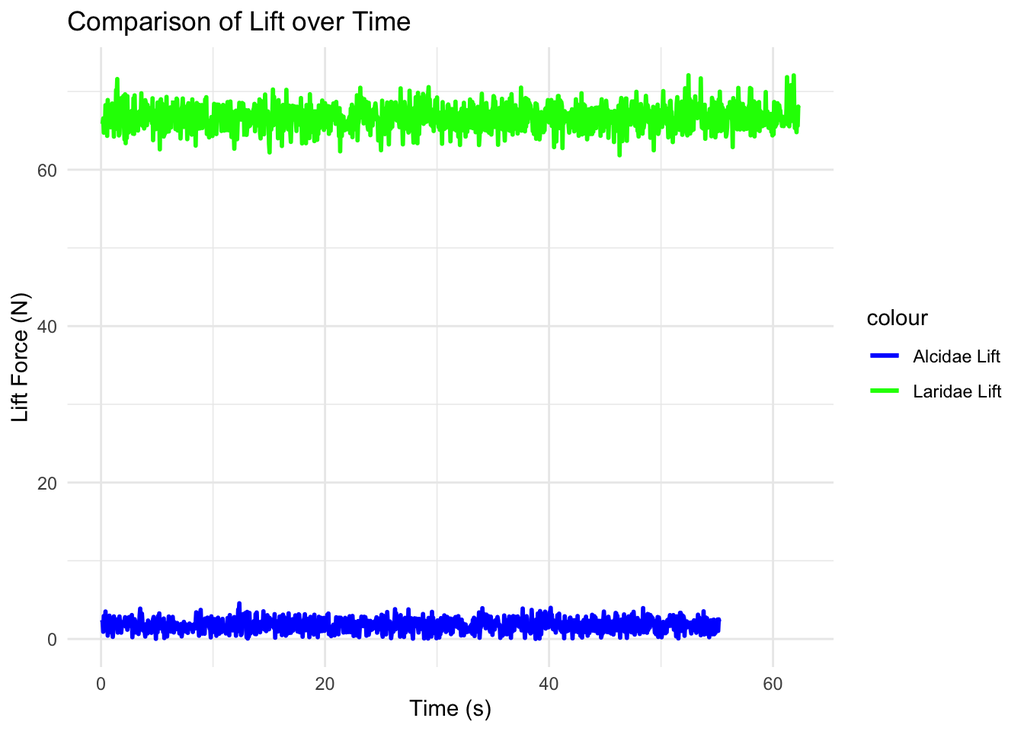

```r
ggplot() +
  geom_line(data = alcidae, aes(x = s, y = lift, color = "Alcidae Lift"), size = 1) +
  geom_line(data = laridae, aes(x = s, y = lift, color = "Laridae Lift"), size = 1) +
  labs(title = "Comparison of Lift over Time", x = "Time (s)", y = "Lift Force (N)") +
  scale_color_manual(values = c("Alcidae Lift" = "blue", "Laridae Lift" = "green")) +
  theme_minimal()
```

## Comparison of Drag over Time b/w Specimens

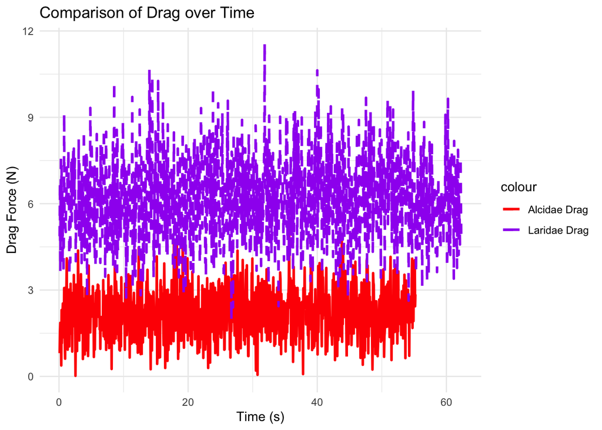

```r
ggplot() +
  geom_line(data = alcidae, aes(x = s, y = drag, color = "Alcidae Drag"), size = 1) +
  geom_line(data = laridae, aes(x = s, y = drag, color = "Laridae Drag"), size = 1, linetype = "dashed") +
  labs(title = "Comparison of Drag over Time", x = "Time (s)", y = "Drag Force (N)") +
  scale_color_manual(values = c("Alcidae Drag" = "red", "Laridae Drag" = "purple")) +
  theme_minimal()
```

## Complete Data Coefficient Graphs b/w Specimens

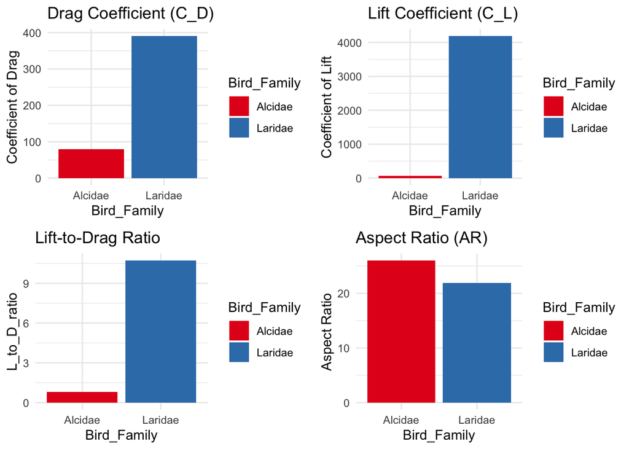

```r
# Arrange the plots in a grid
grid.arrange(p1, p2, p3, p4, ncol = 2, nrow = 2)
```

# Interpretations

### Which birds that inspired the biomimetic wings are likely to soar long periods? That is, which are most likely to glide? Which are unable to soar for long periods?

- Looking at the birds that inspired our biomimetic wings, it seems that species from the Laridae family are more likely to be adept at sustained gliding due to their favorable lift-to-drag ratios. This ability is coherent with the type of habitats they occupy; open environments where they can utilize thermals and air currents to their advantage. Birds like albatrosses utilize dynamic soaring to save energy and soar for extended periods of time. They have the longest known wingspan among birds today, and are able to soar for hours without flapping. Their wings are long and narrow, and as a result have a high aspect ratio. This aspect ratio and wing shape reduces the induced drag and increases lift (Xie and Gao 2023). In contrast, birds like those from the Alcidae family, which show lower ratios, might be less equipped for extended soaring, which could reflect their adaptation to more cluttered environments where agility is more critical than endurance in flight. Birds belonging to the Passeriformes like finches and sparrows are poor gliders. They have shorter, wider wings resulting in a low wing aspect ratio, but high maneuverability and rapid takeoff (Fu and Hefler 2014).

### What tradeoffs can you identify with the ability or inability to soar easily? Related to this, in what type of environment do you suppose each of the birds we’ve explored lives?

- We’ve also contemplated the trade-offs related to the ability or inability to soar. Birds that are adapted for soaring tend to live in environments that allow them to take advantage of consistent wind patterns or thermals. Those that cannot soar as efficiently are often found in environments that demand more agility and less reliance on passive flight mechanisms.
- While their wide wingspans and shorter chord lengths allow them to glide at high speeds for longer, soaring birds lose maneuverability and are unable to turn as quickly (Fu and Hefler 2014). However, soaring birds are found in habitats that have more open areas, whether that be prairies, deserts, by the water, or the open ocean.
- Birds with the inability to soar are unable to sustain high speeds as easily as birds with high wing aspect ratios due to increased induced drag (Xie and Gao 2023). Because of this, birds with low aspect ratio wings are more common to wooded areas and land, in general.

### Consider the lift forces generated by your biomimetic wings. What other adaptations associated with the body would optimize lift resulting from the wing?

- Regarding the body adaptations that would optimize lift, we believe that a streamlined body, reduced weight, and specific tail shapes that contribute to stability and maneuverability in the air are critical. These adaptations, along with wing morphology, work in tandem to optimize the lift generated by the wings.

### Are your results with respect to AR and lift ratio supported by previous studies? If not, consider why.

- According to previous studies, the lift coefficient increases as aspect ratio increases. In spite of this, the Alcidae has a higher aspect ratio than the Laridae. This is unexpected due to the significantly higher lift coefficient associated with the Laridae wing (Xie and Gao 2023). However, the Alcidae wing area is larger than the Laridae wing, which may have contributed to this slightly higher aspect ratio.

### Lastly, using the images you took of your wings in the swim tunnel, address the following: Were the flow patterns at the wing tip different between your two models? If so, how do these differences relate to their lift-to-drag ratios?

- Finally, assessing the flow patterns at the wing tips in our swim tunnel images, we noticed differences between the two models. We were able to see the vortices produced as evidenced by the particles that would be moving backwards as a result of the turbulent flow. While it was difficult to quantify the number of vortices produced between the Alcidae and Laridae wings, we would expect to see more vortices produced by the Alcidae wing due to the larger surface area. These variations likely influence their respective lift-to-drag ratios. For instance, the smoother flow around the Laridae model’s wingtips could explain its higher efficiency compared to the Alcidae. This observation prompts us to think about the real-life implications on the flight capabilities of these birds. The Laridae’s wing structure, which may induce less vortex drag, suggests they are adapted for sustained flight, unlike the Alcidae, which might be more suited to short bursts of flight where maneuverability is key.

# References

Fu, Jun-Jiang, and Csaba Hefler. 2014. “Effects of Aspect Ratio on Flapping Wing Aerodynamics in Animal Flight.” https://doi.org/10.1007/s10409-014-0120-z.

KleinHeerenbrink, Marco, L. Christoffer Johansson, and Anders Hedenström. 2017. “Multi-Cored Vortices Support Function of Slotted Wing Tips of Birds in Gliding and Flapping Flight.” *Journal of The Royal Society Interface*. https://doi.org/10.1098/rsif.2017.0099.

Xie, Changchuan, and Nongyue Gao. 2023. “A Review of Bird-Like Flapping Wing with High Aspect Ratio.” *Chinese Journal of Aeronautics*. https://doi.org/10.1016/j.cja.2022.06.009.